# bayesm_tutorial

Marvin Ward Jr.

December 29, 2015

This is a quick intro to the `bayesm` library, which features a host of bayesian estimators. (Hat tip to the [Laboratory for Interdisciplinary Statistical Analysis](https://vimeo.com/14553953).) The motivation is the need to evaluate a multivariate probit model, which surprisingly few libraries in R or Python support.

```r
library(bayesm)
library(coda)
```

The first thing to do is check out the data. We will be using the popular `cars` dataset.

```r
head(cars)
```

```
##   speed dist
## 1     4    2
## 2     4   10
## 3     7    4
## 4     7   22
## 5     8   16
## 6     9   10
```

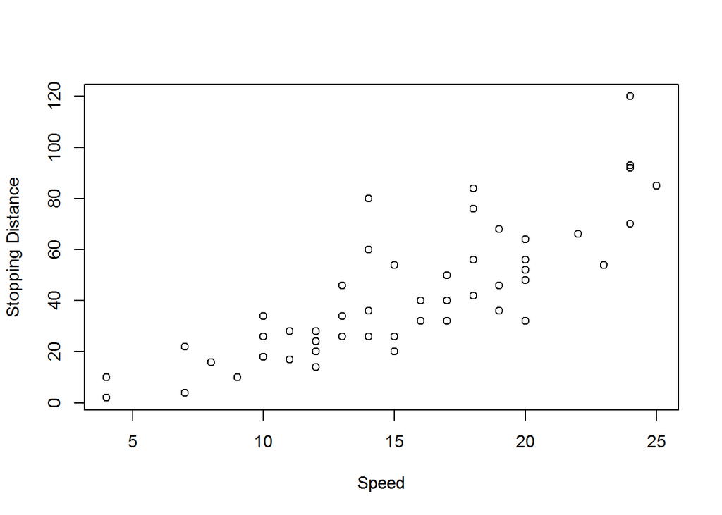

```r
plot(cars$speed,cars$dist,ylab='Stopping Distance',xlab='Speed')
```

Our goal is to evaluate the impact of car speed on stopping distance. We are using the `runiregGibbs` function to perform this analysis. It estimates the betas and the error variance in MLR assuming iid normal errors. It requires 3 arguments:

1. Data
2. Prior
3. MCMC

All of these must be lists.

*Regression Estimation*

Apparently, we need to work with vectors. This is trivial for the dependent $y$, but we must also add a constant column to the design matrix $X$. Once these arrays are constructed (array being used here as a catch all for vectors and matrices), we throw them both into the Data list.

```r
#Convert dependent to vector
y1=as.vector(cars$dist)

#Define constant column
constant=matrix(1,nrow(cars),1)

#Consolidate constant column and independent variable in matrix
X1=cbind(constant,cars$speed)

#Throw both the dependent vector and design matrix into the Data list
Data1=list(y=y1,X=X1)
```

We need to establish priors for both the estimate, $\beta$, and the variance, $\sigma^2$. The former is distributed normally, while the latter features a $\chi^2$ distribution. The arguments we need are as follows:

1. Prior mean (`betabar`)
2. Prior precision matrix (which is the inverse of the variance; `A`)
3. Degrees of freedom (`nu`)
4. Scale parameter (`ssq`)

The first two arguments correspond to $\beta$, while the second to correspond to $\sigma^2$.

```r
#Define prior mean (intercept,slope >> just a list of scalars)
betabar1=c(0,0)

#Define prior precision (dimension is driven by number of coefficients to be estimated)
A1=0.01*diag(2)

#Define degrees of freedom
nu1=3

#Define scale parameter
ssq1=var(y1)

#Conolidate prior info into list
Prior1=list(betabar=betabar1,A=A1,nu=nu1,ssq=ssq1)
```

Finally, we need to tell the sampler how many iterations we want it to run (`R`), and whether or not we want thinning to be performed (taking sparse observations; `keep`).

```r
#Define number of iterations
R1=5000

#Define thinning rate (1 means no thinning)
keep1=1

#Compile MCMC info into list
MCMC1=list(R=R1,keep=keep1)
```

Now we can run the model and check out some diagnostics.

```r
#Run the model
simOut=runiregGibbs(Data1,Prior1,MCMC1)
```

```
##
## Starting Gibbs Sampler for Univariate Regression Model
##   with  50  observations
##
## Prior Parms:
## betabar
## [1] 0 0
## A
##      [,1] [,2]
## [1,] 0.01 0.00
## [2,] 0.00 0.01
## nu =  3  ssq=  664.0608
##
## MCMC parms:
## R=  5000  keep=  1  nprint=  100
```

[output cut: 53 more lines]

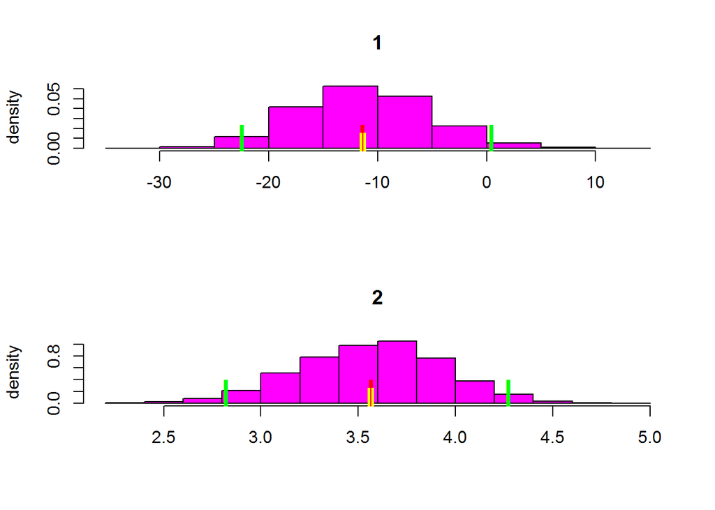

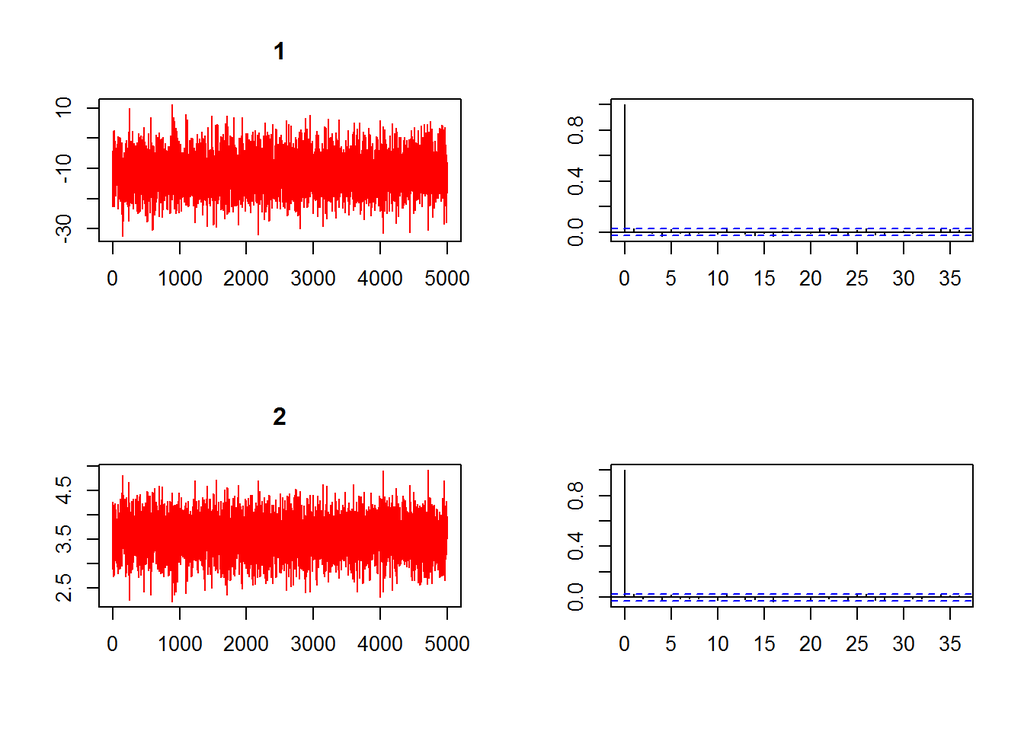

```r
#Plot diagnostics
plot(simOut$betadraw)
```

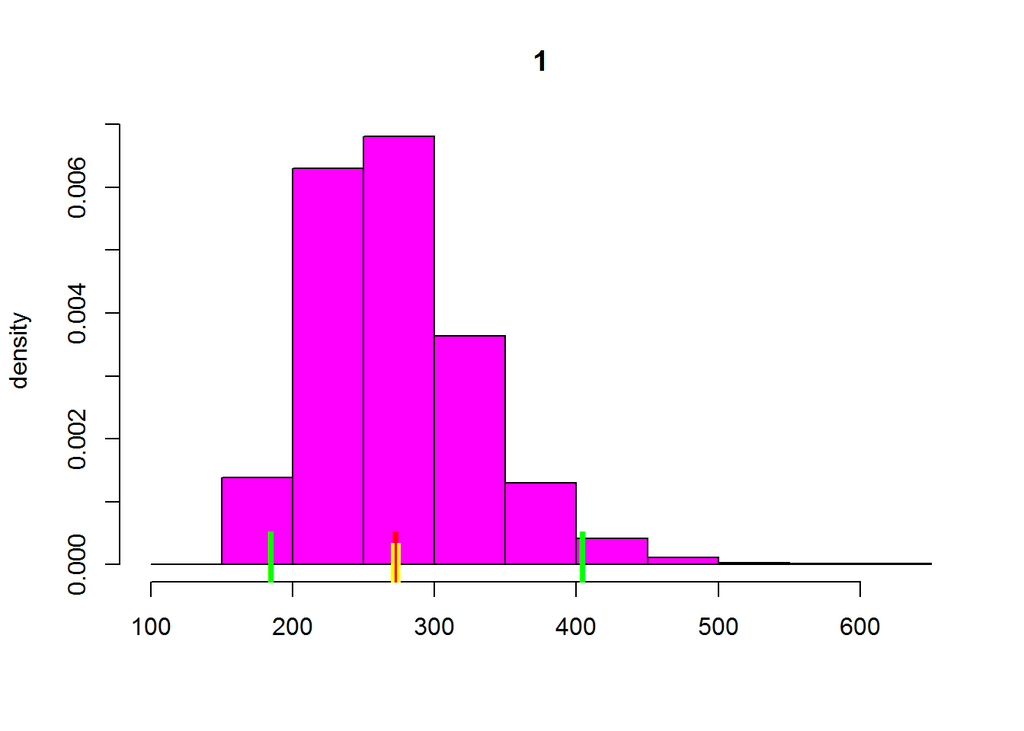

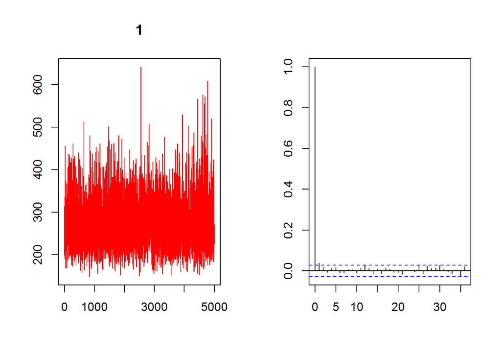

```r
plot(simOut$sigmasqdraw)
```

We can also get printout distributional information with `summary()` commands. Note that the `bayesm` library provides Equal Tail Probability intervals. If we want HPD intervals, we need the `coda` library.

```r
#Capture summaries of both beta and sigmasq
summary(simOut$betadraw)
```

```
## Summary of Posterior Marginal Distributions
## Moments
##    mean std dev num se rel eff sam size
## 1 -11.3    5.96 0.0851    0.92     4500
## 2   3.6    0.37 0.0051    0.85     4500
##
## Quantiles
##    2.5%    5%   50%  95% 97.5%
## 1 -22.4 -20.7 -11.6 -1.4  0.45
## 2   2.8   2.9   3.6  4.2  4.27
##    based on 4500 valid draws (burn-in=500)
```

```r
summary(simOut$sigmasqdraw)
```

[output not shown]

```r
#Capture HPD intervals
HPDinterval(simOut$betadraw)
```

```
##           lower    upper
## var1 -22.468551 0.512833
## var2   2.835676 4.288987
## attr(,"Probability")
## [1] 0.95
```

```r
HPDinterval(simOut$sigmasqdraw)
```

```
##         lower    upper
## var1 174.2134 383.9712
## attr(,"Probability")
## [1] 0.95
```

*Probit Regression*

Now we are going to look at a probit model with multiple regressors. These data look at admission to some program given GRE scores and GPA. Let’s set up the data.

```r
#Read in data
mydata<-read.csv("http://www.ats.ucla.edu/stat/data/binary.csv")

#Inspect data
head(mydata)
```

```
##   admit gre  gpa rank
## 1     0 380 3.61    3
## 2     1 660 3.67    3
## 3     1 800 4.00    1
## 4     1 640 3.19    4
## 5     0 520 2.93    4
## 6     1 760 3.00    2
```

```r
#Capture dependent (apparently we didn't need to convert to vector above?)
y2=mydata$admit

#Capture design matrix
constant2=matrix(1,nrow(mydata),1)
X2=cbind(constant2,mydata$gre,mydata$gpa)

#Consolidate in list
Data2=list(y=y2,X=X2)
```

Now we are setting up our priors. Take note of the changes theat come from an extra regressor. Note also that the distributional information for variance is no longer in play. The convention is to work with standardized variance in probit models of 1.

```r
#Define prior means
betabar2=c(0,0,0)

#Define prior precision matrix
A2=0.01*diag(3)

#Consolidate in list
Prior2=list(betabar=betabar2,A=A2)
```

Again, we conclude set up by setting the number of iterations for the Gibb sampler, and setting keep behavior.

```r
#Define number of iterations
R2=10000

#Define keep behavior
keep2=1

#Consolidate in list
MCMC2=list(R=R2,keep=keep2)
```

This time we will be using the `rbprobitGibbs()` estimator. Let’s estimate our posterior for $\beta$ and see what we get.

```r
#Fit model
simOut2=rbprobitGibbs(Data2,Prior2,MCMC2)
```

```
##
## Starting Gibbs Sampler for Binary Probit Model
##    with  400  observations
## Table of y Values
## y
##   0   1
## 273 127
##
## Prior Parms:
## betabar
## [1] 0 0 0
## A
##      [,1] [,2] [,3]
## [1,] 0.01 0.00 0.00
## [2,] 0.00 0.01 0.00
```

[output cut: 107 more lines]

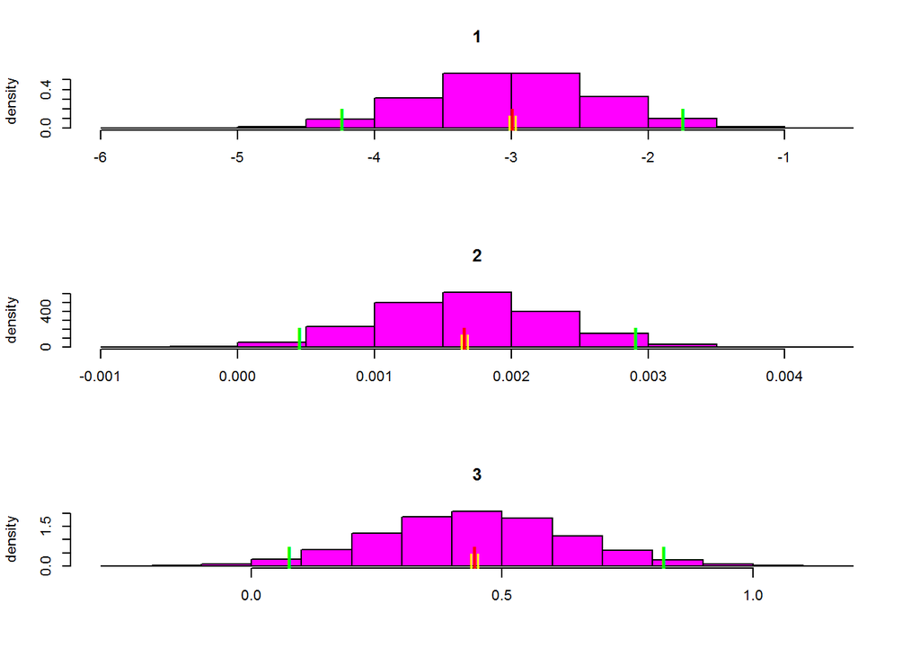

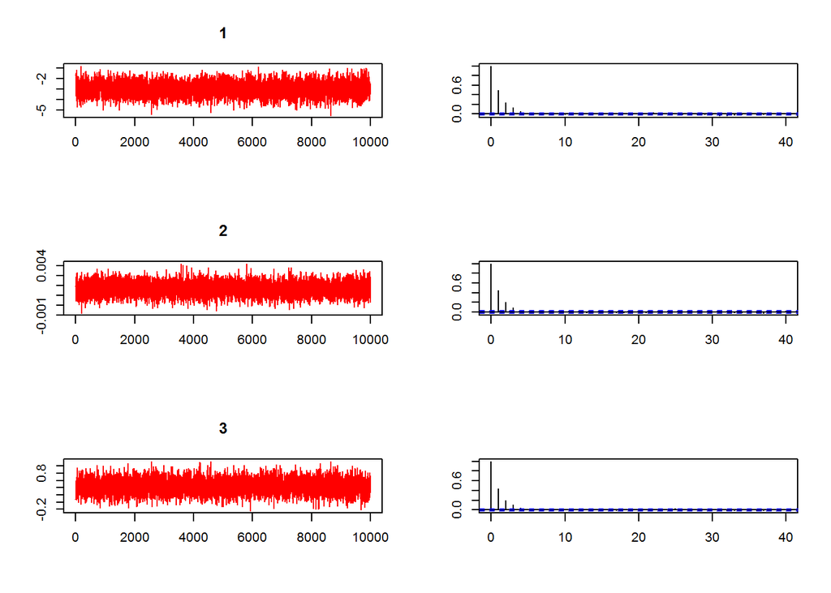

```r
#Plot posterior distribution
plot(simOut2$betadraw)
```

```r
#Check out summary
summary(simOut2$betadraw)
```

[output not shown]